# Is it worth learning how to drive stick shift?

Jeewesh Jha

# Introduction

One of the gretest debate about cars is on the transmission type. While the manual transmission is on its extinction in the US, they are [still very popular in Europe](http://www.dctfacts.com/archive/2008/why-dual-clutch-technology-big-business.aspx). One often stated advantage of manual transmission over automatic one is the fuel efficiency. The purpose of this analysis is to find if there is any relationship between a set of variables and miles per gallon (MPG). Is it worth learning how to drive stick shift or buy one despite the challenging stop-and-go on hills?

# Data analysis

`mtcars` dataset was used for the analysis. It comprises fuel consumption and 10 aspects of automobile design and performance for 32 automobiles (1973-1974).

```r
attach(mtcars)
```

The following boxplot shows the relation between the transmission type and the MPG.

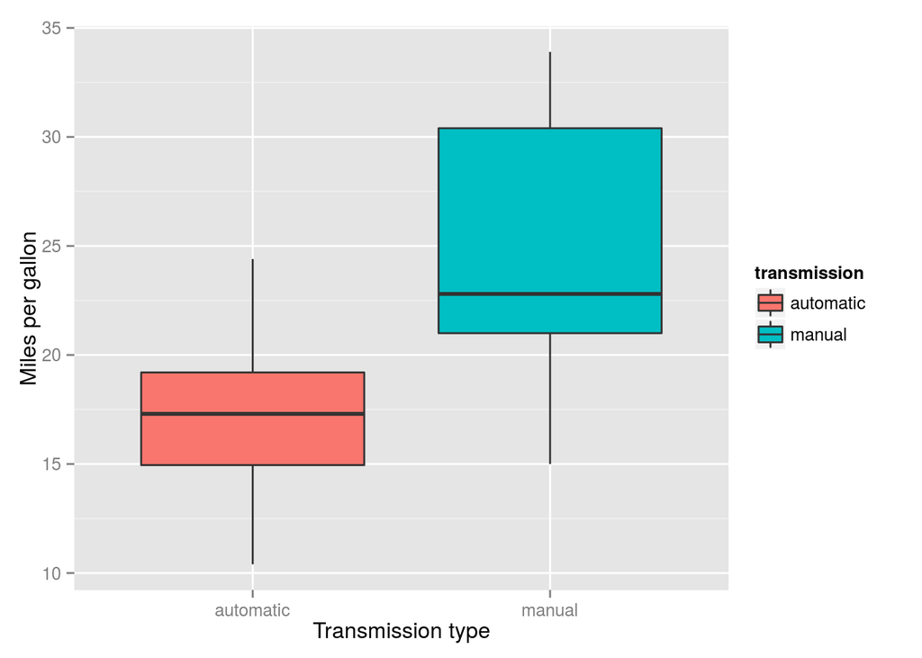

```r
library(plyr)
library(ggplot2)
# Rename the levels of transmission types
transmission <- revalue(as.factor(am), c('0'="automatic", '1'="manual"))
ggplot(mtcars, aes(x=transmission, y=mpg, fill=transmission)) +
    geom_boxplot() +
    xlab("Transmission type") +
    ylab("Miles per gallon")
```

It suggests a clear difference on fuel consumption between automatic and manual transmission cars. Below is the model to explain the MPG variability with the transmission type *only*.

```r
fit1 <- lm(mpg ~ am, data=mtcars)
summary(fit1)
```

```
##
## Call:
## lm(formula = mpg ~ am, data = mtcars)
##
## Residuals:
##    Min     1Q Median     3Q    Max
## -9.392 -3.092 -0.297  3.244  9.508
##
## Coefficients:
##             Estimate Std. Error t value Pr(>|t|)
## (Intercept)    17.15       1.12   15.25  1.1e-15 ***
## am              7.24       1.76    4.11  0.00029 ***
## ---
## Signif. codes:  0 '***' 0.001 '**' 0.01 '*' 0.05 '.' 0.1 ' ' 1
##
## Residual standard error: 4.9 on 30 degrees of freedom
## Multiple R-squared:  0.36,   Adjusted R-squared:  0.338
## F-statistic: 16.9 on 1 and 30 DF,  p-value: 0.000285
```

Although coefficients for both intercept and the transmission type are significant, the model fit using *only* transmission type explains only 35.9799% of the MPG variation.

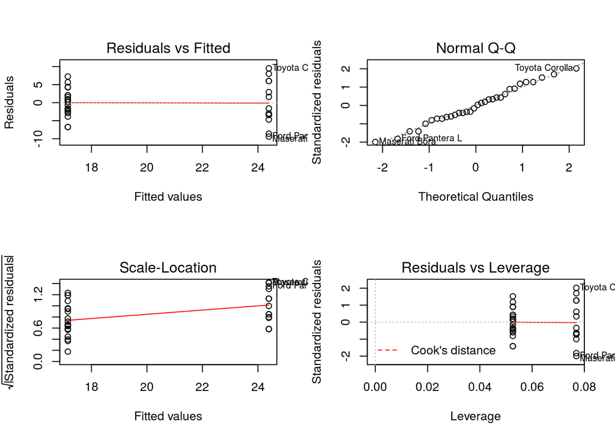

```r
par(mfrow = c(2,2))
plot(fit1)
```

```r
fit2 <- lm(mpg ~ ., data=mtcars)
summary(fit2)
```

```
##
## Call:
## lm(formula = mpg ~ ., data = mtcars)
##
## Residuals:
##    Min     1Q Median     3Q    Max
##  -3.45  -1.60  -0.12   1.22   4.63
##
## Coefficients:
##             Estimate Std. Error t value Pr(>|t|)
## (Intercept)  12.3034    18.7179    0.66    0.518
## cyl          -0.1114     1.0450   -0.11    0.916
## disp          0.0133     0.0179    0.75    0.463
## hp           -0.0215     0.0218   -0.99    0.335
## drat          0.7871     1.6354    0.48    0.635
## wt           -3.7153     1.8944   -1.96    0.063 .
## qsec          0.8210     0.7308    1.12    0.274
## vs            0.3178     2.1045    0.15    0.881
## am            2.5202     2.0567    1.23    0.234
## gear          0.6554     1.4933    0.44    0.665
## carb         -0.1994     0.8288   -0.24    0.812
## ---
## Signif. codes:  0 '***' 0.001 '**' 0.01 '*' 0.05 '.' 0.1 ' ' 1
##
## Residual standard error: 2.65 on 21 degrees of freedom
## Multiple R-squared:  0.869,  Adjusted R-squared:  0.807
## F-statistic: 13.9 on 10 and 21 DF,  p-value: 3.79e-07
```